# Day 4. RNASeq downsteam analysis, Part 2

by Zuguang Gu (z.gu@dkfz.de), 2017-12-13 21:14:24. The github repository for this material is at https://github.com/eilslabs/teaching.

We will use the three objects `count`, `deseq2` and `anno` which have been generated on day 3. If you forget how to generate them, just run following code:

```r
library(airway)  # load the airway package
data(airway)
count = assay(airway)

library(DESeq2)
deseq2 = vst(count)

anno = as.data.frame(colData(airway))
anno = anno[, c("cell", "dex")]
```

## Differential expression analysis by classical statistical test

Generally, to compare two groups which are represented as two numeric vectors, we use t-test if we assume the data follows a normal distribution or a rank-based test like [Wilcoxon test](https://en.wikipedia.org/wiki/Mann%E2%80%93Whitney_U_test) if we test it non-parametricly (here “non-parametric” means no prior statistical distribution is assumed for the data).

First we test whether the 3rd gene is differentially expressed between “trt” and “untrt” conditions.

```r
# recall we need to use the normalized values to compare between samples
x = deseq2[3, ]
# extract the expression values in "trt" group
x1 = x[anno$dex == "trt"]
# extract the expression values in "untrt" group
x2 = x[anno$dex == "untrt"]
```

`t.test()` function can be applied to `x1` and `x2` to perform t-test:

```r
t.test(x1, x2)
```

```
##
##  Welch Two Sample t-test
##
## data:  x1 and x2
## t = 3.5933, df = 4.2276, p-value = 0.02084
## alternative hypothesis: true difference in means is not equal to 0
## 95 percent confidence interval:
##  0.04652325 0.33567163
## sample estimates:
## mean of x mean of y
##  9.227406  9.036308
```

We can see the p-value is significant (< 0.05), which means this gene is significantly differentially epxressed between “trt” and “untrt” groups.

We can confirm it by looking at the boxplot.

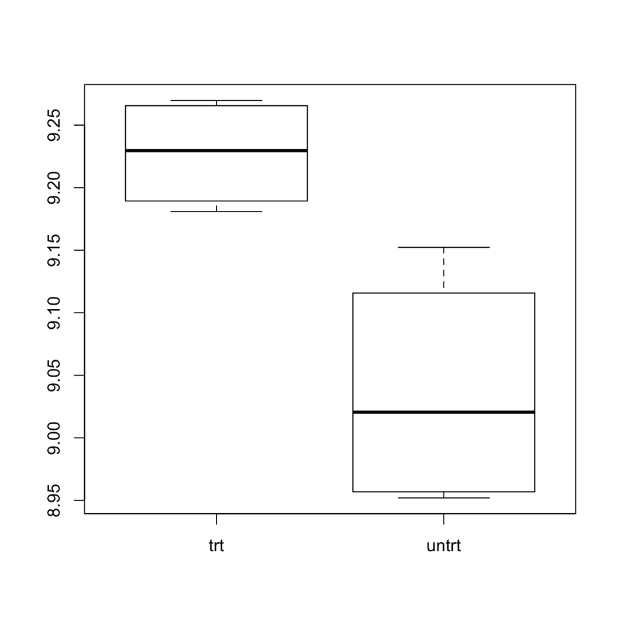

```r
boxplot(list(trt = x1, untrt = x2))
```

The results returned by `t.test()` can be assigned to a variable.

```r
test = t.test(x1, x2)
```

And the p-value can be obtained from `test` variable.

```r
# e.g. the p-value
test$p.value
```

```
## [1] 0.02084481
```

Next we test differential expression of the 12th gene similarly by t-test.

```r
x = deseq2[12, ]
x1 = x[anno$dex == "trt"]
x2 = x[anno$dex == "untrt"]
t.test(x1, x2)
```

```
##
##  Welch Two Sample t-test
##
## data:  x1 and x2
## t = -0.12009, df = 5.9992, p-value = 0.9083
## alternative hypothesis: true difference in means is not equal to 0
## 95 percent confidence interval:
##  -0.8521257  0.7724008
## sample estimates:
## mean of x mean of y
##  11.40061  11.44047
```

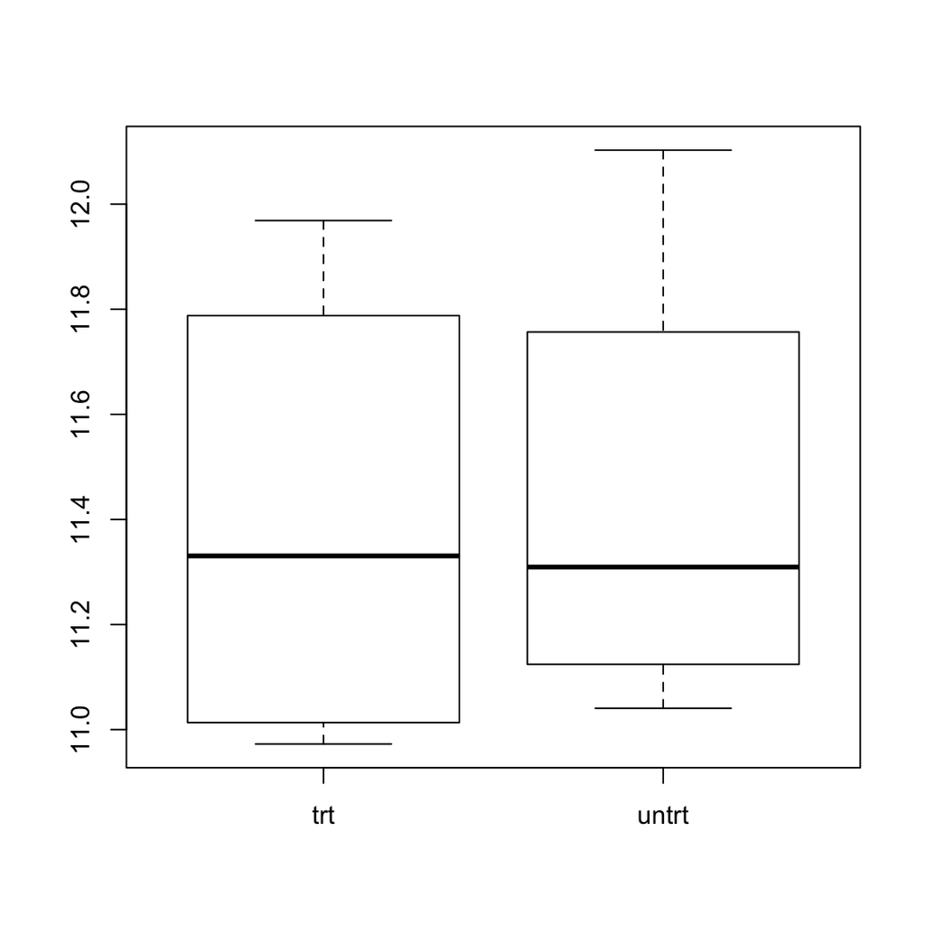

```r
boxplot(list(trt = x1, untrt = x2))
```

We can see this gene almost shows no difference between “trt”/“untrt”.

We can test these two genes by the non-parametric Wilcoxon rank-based test by the `wilcox.test()` function.

```r
x = deseq2[3, ]
x1 = x[anno$dex == "trt"]
x2 = x[anno$dex == "untrt"]
wilcox.test(x1, x2)
```

```
##
##  Wilcoxon rank sum test
##
## data:  x1 and x2
## W = 16, p-value = 0.02857
## alternative hypothesis: true location shift is not equal to 0
```

```r
x = deseq2[12, ]
x1 = x[anno$dex == "trt"]
x2 = x[anno$dex == "untrt"]
wilcox.test(x1, x2)
```

```
##
##  Wilcoxon rank sum test
##
## data:  x1 and x2
## W = 7, p-value = 0.8857
## alternative hypothesis: true location shift is not equal to 0
```

You may see the p-values are difference between different testing methods. This is what it should be because the p-value is always calculated from the distribution of the null hypothesis and different tests have different null hypothesis, however, the p-value should not differ too much.

For the complete gene expression data, we need to apply testing for all genes. We can do it in a `for` loop or simply use `apply()` function.

```r
p_value_t_test = apply(deseq2, 1, function(x) {
    x1 = x[anno$dex == "trt"]
    x2 = x[anno$dex == "untrt"]
    if(length(unique(x1)) == 1 || length(unique(x2)) == 1) {
        return(NA)
    } else {
        t = t.test(x1, x2)
        return(t$p.value)
    }
})
```

If above code, the self-defined function will be applied to each row in `deseq2` matrix.

For `x1` and `x2` which are involved in the t-test, both vectors should have at least two distinct values, and that is way we assign `NA` if `x1` or `x2` has no enough data points.

Here we don’t suggest to use Wilcoxon test for this dataset because the number of data points in the two groups (which is 4) are too small.

## Multiple testing

Each gene is applied by a test and has a p-value. The p-value means the probability that the data follows the null hypothesis. E.g. if a gene has a p-value of 0.01, it means the probability of saying “trt”/“untrt” has no difference is 0.01. Or in other words, the probability of the conclusion “the gene is differentially expressed between trt/untrt” is wrong is 0.01. (This explanation is not strictly correct, but you can understand like just like that.)

As long as the p-value is not exactly zero, there is always probability that the genes you call “significantly differentially expressed” are not true or they are false positives. Let’s image a simple scenario. Assume you have 10000 genes and all genes have p-value of 0.01. Will you take all 10000 genes as differnetially expressed genes? We can simply calculate the probability of at least one false positive: `1-(1-0.01)^10000` which is almost 100% true. In other words, for these 10000 genes, there must be at least one gene which is false positive. Thus, we need to adjust the raw p-values to reduce false positives when you do more than one statistic test (or formally called mulitple testing).

There are several methods that you can check in the document of `p.adjust()` function. One of the most used method is called the “BH” method.

```r
adjp = p.adjust(p_value_t_test, method = "BH")
```

Check how many genes have p-values < 0.05 and how many genes have adjusted p-values < 0.05.

```r
sum(p_value_t_test < 0.05, na.rm = TRUE)
```

```
## [1] 4364
```

```r
sum(adjp < 0.05, na.rm = TRUE)
```

```
## [1] 267
```

By looking these two numbers, you can have an impression of how many the false positives are there if you do not apply p-value adjustment.

## Differential expression by DESeq2

When you do statistical test, there is always a null hypothesis (e.g. t-test assume the data follows a normal distribution). For RNASeq data which is count-based data, **DESeq2** package provides a more proper test which is designed for count-based data.

Before we apply **DESeq2** analysis, we need to convert `anno$dex` to a factor. Here `levels` of `anno$dex` is important for calculating log2 fold change. If `levels == c("untrt", "trt")`, a positive log2 fold change means the gene is highly expressed in `trt` group. Thus the log2 fold change is calculated as `log2(trt/untrt)`.

```r
anno$dex = factor(anno$dex, levels = c("untrt", "trt"))
```

Following code performs the DESeq2 differential expression analysis:

```r
# construct the data structure for the analysis
dds = DESeqDataSetFromMatrix(countData = count,
                             colData   = anno,
                             design    = ~ dex)
# perform the analysis
dds = DESeq(dds)
# retrieve the results
res = results(dds)
# convert to the data frame
res_dex = as.data.frame(res)
head(res_dex)
```

```
##                    baseMean log2FoldChange     lfcSE       stat     pvalue
## ENSG00000000003 708.6021697    -0.36076055 0.1648637 -2.1882354 0.02865246
## ENSG00000000005   0.0000000             NA        NA         NA         NA
## ENSG00000000419 520.2979006     0.20037122 0.0988954  2.0260923 0.04275533
## ENSG00000000457 237.1630368     0.03315858 0.1229655  0.2696575 0.78742375
## ENSG00000000460  57.9326331    -0.10169404 0.2614920 -0.3888992 0.69735068
## ENSG00000000938   0.3180984    -0.08980382 0.1614546 -0.5562173 0.57806230
##                      padj
## ENSG00000000003 0.1392880
## ENSG00000000005        NA
## ENSG00000000419 0.1830287
## ENSG00000000457 0.9306857
## ENSG00000000460 0.8956152
## ENSG00000000938        NA
```

When there is `NA` in the table, it means the counts for the gene are all (or majority) zero and not enough for the test.

The columns in `res_dex` are:

- `baseMean`: the row means of the count table which is the mean expression level for genes across samples
- `log2FoldChange`: log2 fold change between trt and untrt
- `lfsSE`: standard error of the log2 fold change
- `stat`: the statistics from the test
- `pvalue`: raw p-values
- `padj`: adjusted p-values

Check how many genes are significantly differentially expressed if we set the significance level to 0.05.

```r
sum(res_dex$padj < 0.05, na.rm = TRUE)
```

```
## [1] 2699
```

We can check the overlap of the differential genes from DESeq2 method and t-test:

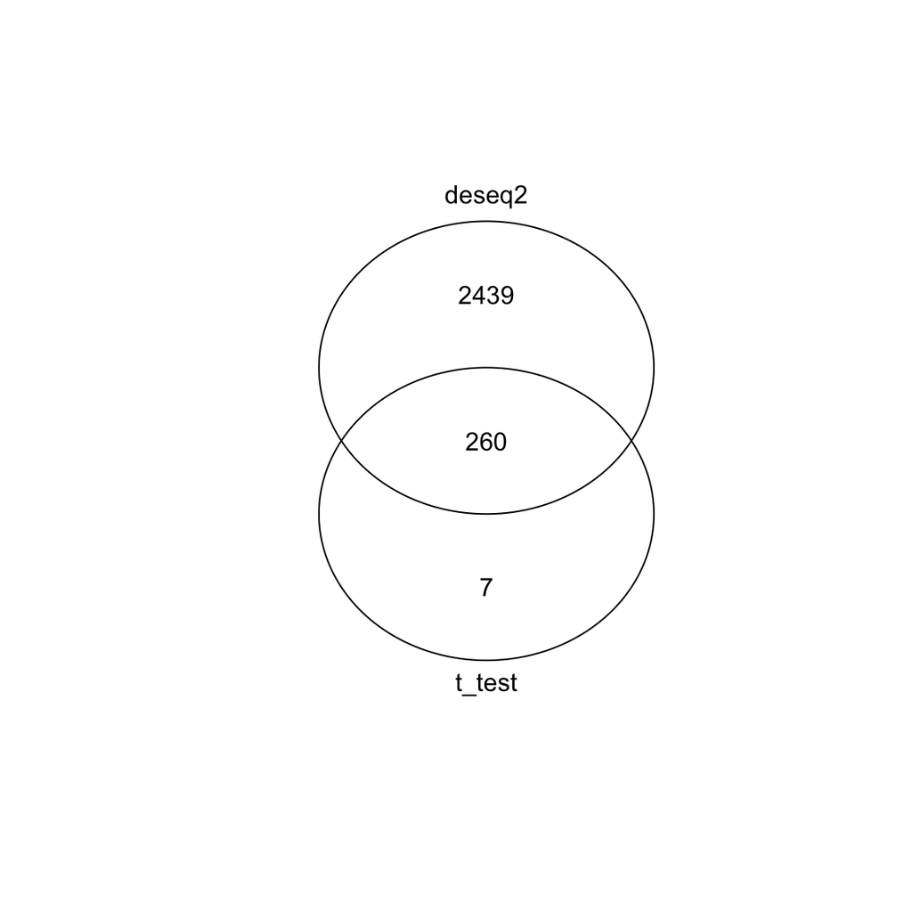

```r
library(gplots) # run install.packages("gplots") if not installed
plot(venn(list(t_test = which(adjp < 0.05), deseq2 = which(res_dex$padj < 0.05))))
```

We can see the DESeq2 method is more powerful than the t-test because DESeq2 has a more proper null hypothesis or null distribution for testing.

In the DESeq2 results `res_dex`, there are several statistics which are important for interpretation of the results. We need `baseMean` to know the expression level of genes, we need `log2FoldChange` to know how much the gene is differentially expressed between the two groups, and we need `padj` to know which difference is significant. A so-called “MA-plot” can visualize these three statistics at a same time.

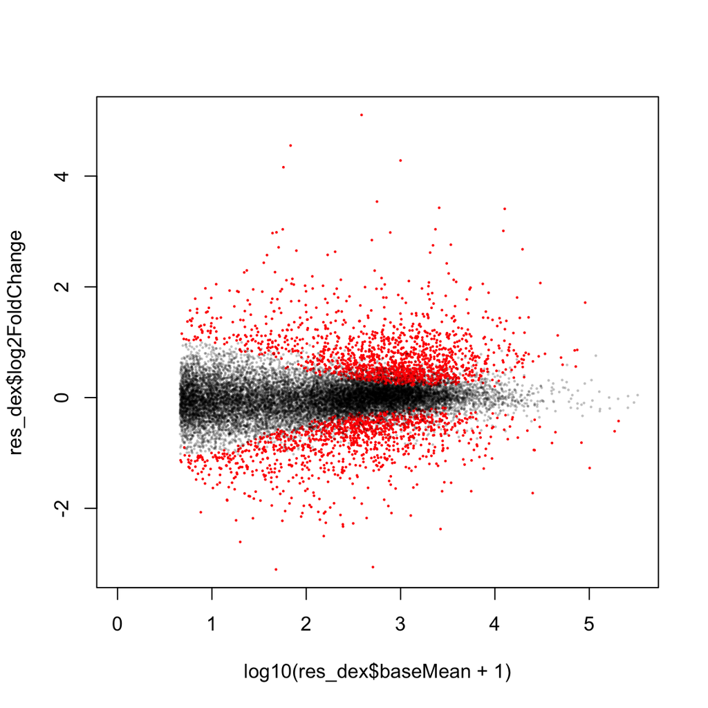

```r
plot(log10(res_dex$baseMean + 1), res_dex$log2FoldChange, pch = 16, cex = 0.3,
    col = ifelse(res_dex$padj < 0.05, "red", "#00000040"))
```

In the MA-plot, significant genes are marked as red points. From above plot, it generally shows when genes have lower expression, the log2 fold change should be higher to be called significant, and secondly, the majority of differential genes are intermeidately expressed (at around x = 3).

After we have a list of differential genes, we can visualize the expression of them as a heamtap.

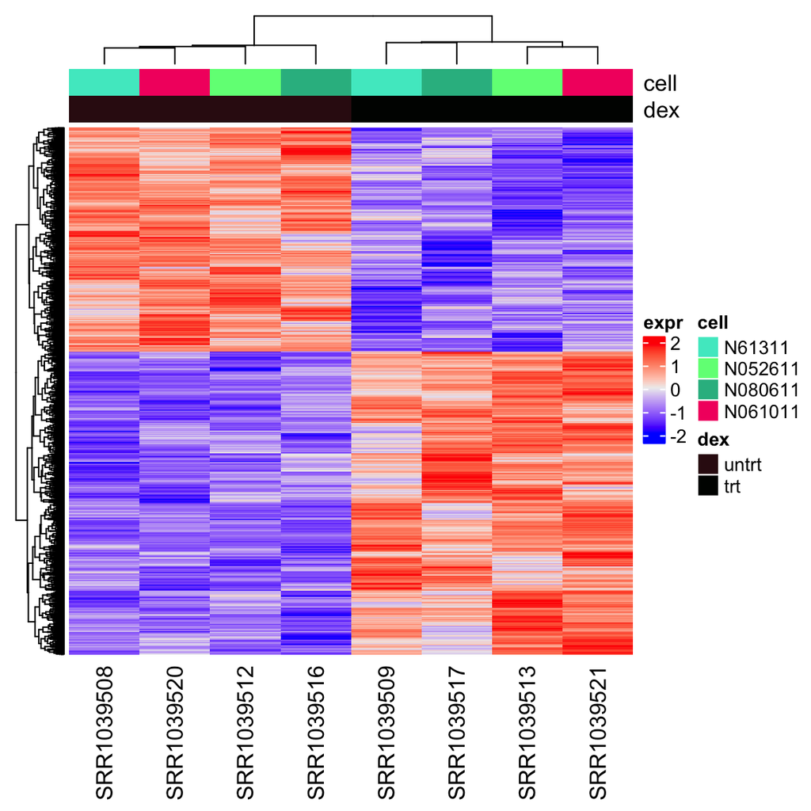

```r
library(ComplexHeatmap)
index_sig = which(res_dex$padj < 0.05)
mat = deseq2[index_sig, ]
mat_scaled = t(scale(t(mat)))
Heatmap(mat_scaled, name = "expr", show_row_names = FALSE,
    top_annotation = HeatmapAnnotation(df = anno, show_annotation_name = TRUE)
)
```

For showing the heamtap of differentially expressed genes, we usually use the matrix scaled by rows. You can compare to the original matrix:

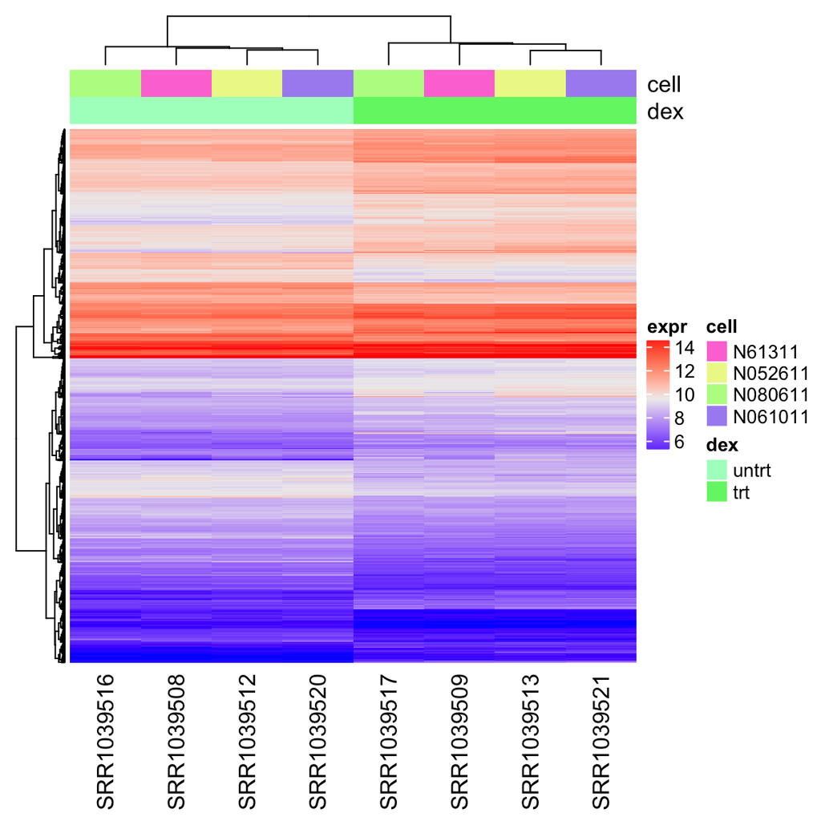

```r
Heatmap(mat, name = "expr", show_row_names = FALSE,
    top_annotation = HeatmapAnnotation(df = anno, show_annotation_name = TRUE)
)
```

Similarly, we can look for differentially expressed genes for different cell types:

```r
dds = DESeqDataSetFromMatrix(countData = count,
                             colData   = anno,
                             design    = ~ cell)  # <<== we change here
dds = DESeq(dds)
res = results(dds)
res_cell = as.data.frame(res)
# how many differentially expressed genes
sum(res_cell$padj < 0.05, na.rm = TRUE)
```

```
## [1] 416
```

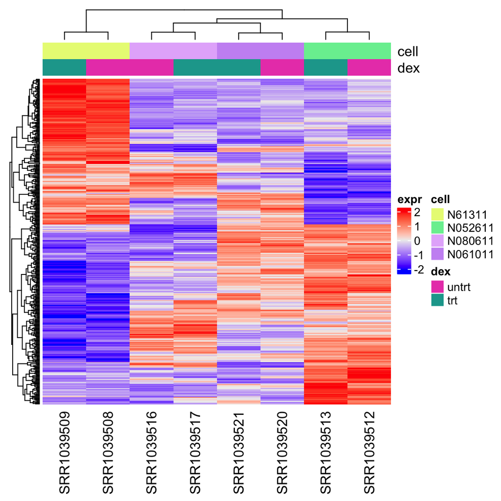

```r
index_sig = which(res_cell$padj < 0.05)
mat = deseq2[index_sig, ]
mat_scaled = t(scale(t(mat)))
Heatmap(mat_scaled, name = "expr", show_row_names = FALSE,
    top_annotation = HeatmapAnnotation(df = anno, show_annotation_name = TRUE)
)
```

## Functional enrichment

Once we have a list of differetially expressed genes, the next step is always to look for the biological functions that the genes are enriched in.

Normally we use [Fisher’s exact test](https://en.wikipedia.org/wiki/Fisher%27s_exact_test) to test the enrichment. Assume $k_{10}$ is the number of differential genes, $k_{01}$ is the number of genes annotated in a biological function (or called a term, which is normally from public database), $k_{11}$ is the number of differential genes which have the biological function and $k_{00}$ is the number of background genes (e.g. total number of human genes). Following 2x2 contingency table is constructed.

|  | has function | no function | total |
| --- | --- | --- | --- |
| is diff | k_11 | k_10 - k_11 | k_10 |
| not diff | k_01 - k_11 | k_00 - k_01 - k_10 + k _11 | k_00 - k_10 |
| total | k_01 | k_00 - k_01 | k_00 |

If differential genes are enriched in the biological function, $k_{11}$ is significantly higher than if they are not enriched. Fisher’s exact test is designed to test this type of enrichment.

In R, we use **clusterProfiler** package (http://www.bioconductor.org/packages/release/bioc/html/clusterProfiler.html) to perform enrichment analysis. Install it if you haven’t had it yet:

```r
source("https://bioconductor.org/biocLite.R")
biocLite("clusterProfiler")
biocLite("org.Hs.eg.db")
```

In following example, we enrich genes which are highly expressed in “trt” to biological functions.

```r
library(clusterProfiler)
up_index = which(res_dex$padj < 0.05 & res_dex$log2FoldChange > 0)
up_genes = rownames(res_dex[up_index, ])
head(up_genes)
```

```
## [1] "ENSG00000002834" "ENSG00000003402" "ENSG00000003987" "ENSG00000004059"
## [5] "ENSG00000004700" "ENSG00000005007"
```

The biological terms (e.g. [Gene Ontology](http://www.geneontology.org/) terms or [KEGG pathway](http://www.genome.jp/kegg/pathway.html) terms) are always from public databases. To enrich differential genes to biological terms, we need to map genes to biological terms first. One of the most common problem is the inconsistency between gene IDs for differential genes and the gene IDs for genes in biological terms.

`up_genes` use Ensembl IDs as gene ID while for the Gene Ontology terms which we will use later, the gene IDs are NCBI Entrez IDs. First we need to convert Ensembl IDs to Entrez IDs.

**clusterProfiler** provides a `bitr()` function which is easy to convert between different gene ID types.

```r
mapping = bitr(up_genes, fromType = "ENSEMBL", toType = "ENTREZID", OrgDb = "org.Hs.eg.db")
up_genes = unique(mapping[, 2])
head(up_genes)
```

```
## [1] "3927" "8837" "9108" "381"  "5965" "5976"
```

You may see there are warnings saying the mapping is not 100%. There are two reasons. First the genes in our analysis also contains non-protein coding genes which do not have a Entrez ID and the second reason is the mapping between different ID types in different public databases is normally not 100% match. But basically it won’t affect the enrichment analysis.

Run `enrichGO()` to perfrom GO enrichment analysis. in `OrgDb = org.Hs.eg.db` part, `org.Hs.eg.db` is a human gene database which is already processed by Bioconductor and `ont` controls the category of GO terms where `BP` correspond to `biological functions`, `MF` corresponds to `molecular functions` and `CC` corresponds to `cellular components`. Check the document of `enrichGO()` for more detailed explanation.

```r
go = enrichGO(gene = up_genes, OrgDb = org.Hs.eg.db, ont = "BP")
head(go)
```

```
##                    ID                                   Description
## GO:0006979 GO:0006979                  response to oxidative stress
## GO:1901653 GO:1901653                  cellular response to peptide
## GO:1901652 GO:1901652                           response to peptide
## GO:0007015 GO:0007015                   actin filament organization
## GO:0071375 GO:0071375 cellular response to peptide hormone stimulus
## GO:0048514 GO:0048514                    blood vessel morphogenesis
##            GeneRatio   BgRatio       pvalue     p.adjust       qvalue
## GO:0006979   63/1294 376/16672 4.417658e-09 2.264492e-05 1.933074e-05
## GO:1901653   53/1294 304/16672 1.909363e-08 4.893697e-05 4.177485e-05
## GO:1901652   66/1294 425/16672 4.123220e-08 7.045208e-05 6.014114e-05
## GO:0007015   54/1294 323/16672 6.071050e-08 7.780050e-05 6.641409e-05
## GO:0071375   49/1294 287/16672 1.276010e-07 1.308166e-04 1.116711e-04
## GO:0048514   71/1294 487/16672 1.654629e-07 1.413605e-04 1.206718e-04
##                                                                                                                                                                                                                                                                                                          …
## GO:0006979                                       5536/2730/5663/3717/5625/3091/1471/9688/2936/5516/3315/9124/…
## GO:1901653                                                                                     5577/2844/10580/3717/688/858/857/23189/10014/5573/59345/5420…
## GO:1901652                      5577/2844/10580/3717/4792/688/858/857/23189/10014/5573/1432/…
## GO:0007015                                                                  6093/9948/285527/55604/10580/3717/28984/23189/4739/8936/6722…
## GO:0071375                                                                                                          5577/2844/10580/3717/858/857/23189/10014/5573/59345/54206/80…
## GO:0048514 79602/1890/639/51564/28996/6093/6095/3091/688/28984/857/3315…
##            Count
## GO:0006979    63
## GO:1901653    53
## GO:1901652    66
## GO:0007015    54
## GO:0071375    49
## GO:0048514    71
```

Now `go` contains significant functions where the differential genes are enriched in.

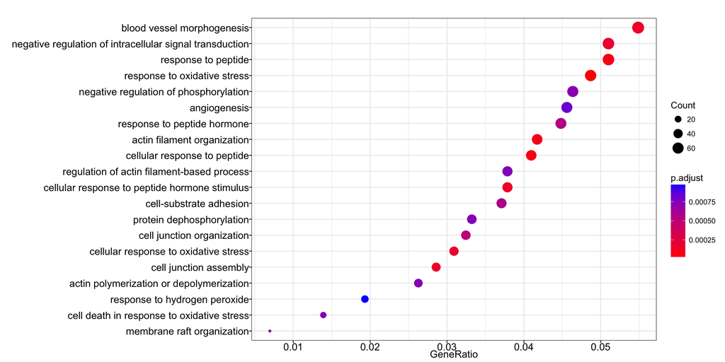

```r
dotplot(go, showCategory = 20)
```

To save it into local file, first convert it to data frame and use `write.table()` to write into a file.

```r
go = as.data.frame(go)
write.csv(go, file = "go_bp_enrichment.csv")
```

We can do similarly for KEGG pathway enrichment. Note the argument is slightly different from `enrichGO()`, you need to check the document of `enrichKEGG()` for full usage.

```r
kegg = enrichKEGG(gene = up_genes, organism = 'hsa')
head(kegg)
```

```
##                ID                      Description GeneRatio  BgRatio
## hsa04510 hsa04510                   Focal adhesion    49/630 199/7314
## hsa04722 hsa04722   Neurotrophin signaling pathway    31/630 119/7314
## hsa05205 hsa05205          Proteoglycans in cancer    42/630 203/7314
## hsa05220 hsa05220         Chronic myeloid leukemia    23/630  78/7314
## hsa04810 hsa04810 Regulation of actin cytoskeleton    42/630 212/7314
## hsa04140 hsa04140               Autophagy - animal    30/630 128/7314
##                pvalue     p.adjust       qvalue
## hsa04510 5.767795e-12 1.678428e-09 1.135345e-09
## hsa04722 1.195395e-08 1.739300e-06 1.176520e-06
## hsa05205 5.228832e-08 5.071967e-06 3.430848e-06
## hsa05220 7.976599e-08 5.802976e-06 3.925327e-06
## hsa04810 1.883506e-07 1.096201e-05 7.415066e-06
## hsa04140 2.661904e-07 1.291023e-05 8.732912e-06
##                                                                                                                                                                                                                                                     geneID
## hsa04510 7414/3909/3918/4659/6093/60/8516/1286/3912/6655/10627/1311/8…
## hsa04722                                                                                        6196/5663/11213/6655/4792/3551/4793/1432/2309/5290/5908/5894/6272/5879/396/5295/53358/5598/27018/1398/5604/3667/5293/5970/5781/4217/5336/801/805/4215/4893
## hsa05205                                 4659/406991/6093/60/6655/3091/858/857/1432/868/5290/3709/547…
## hsa05220                                                                                                                                 9846/4616/6655/4792/3551/868/5290/6776/5894/4609/5925/5295/53358/861/7048/1398/5604/5293/5970/6777/5781/4893/1147
## hsa04810                            7414/4659/6093/27006/60/8516/6655/10627/2259/28964/8936/5159…
## hsa04140                                                                                  8837/11345/23604/81671/55062/58476/9706/51100/3091/5516/6009/10645/5290/6237/5894/5562/22800/3480/9711/5295/26100/64419/1613/5604/3667/5293/8660/2475/79065/4893
##          Count
## hsa04510    49
## hsa04722    31
## hsa05205    42
## hsa05220    23
## hsa04810    42
## hsa04140    30
```

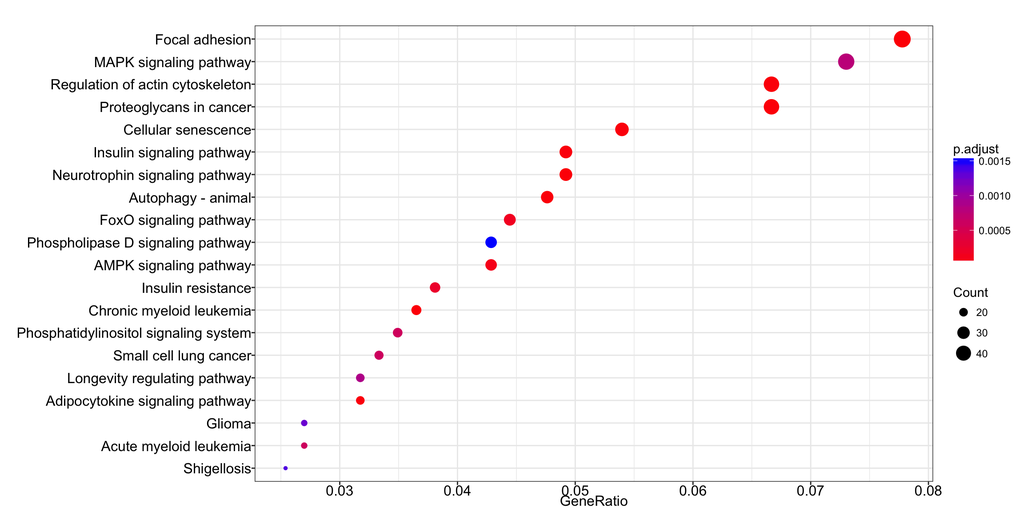

```r
dotplot(kegg, showCategory = 20)
```

```r
kegg = as.data.frame(kegg)
write.csv(kegg, file = "kegg_enrichment.csv")
```

## Exercise

#### task

Can you do GO and KEGG enrichment for the genes which are **down-regulated** in “trt” group and compare the enriched functions/pathways to those of the “trt” up-regulated genes?

Steps:

1. get the gene list which are down-regulated in trt group
2. convert to Entrez IDs
3. do GO enrichment or KEGG enrichment
4. extract the GO/KEGG ids by e.g. `go$ID`
5. use `venn()` from **gplots** package to make Venn diagram

#### solution

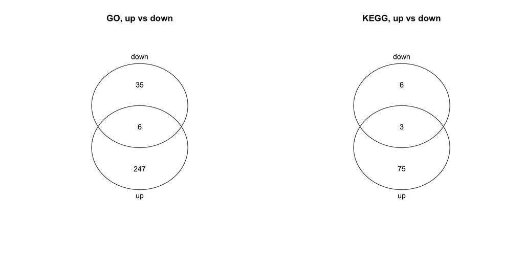

```r
down_index = which(res_dex$padj < 0.05 & res_dex$log2FoldChange < 0)
down_genes = rownames(res_dex[down_index, ])
mapping = bitr(down_genes, fromType = "ENSEMBL", toType = "ENTREZID", OrgDb = "org.Hs.eg.db")
down_genes = unique(mapping[, 2])
go_down = enrichGO(gene = down_genes, OrgDb = org.Hs.eg.db, ont = "BP")
kegg_down = enrichKEGG(gene = down_genes, organism = 'hsa')

library(gplots)
par(mfrow = c(1, 2))
venn(list(up = go$ID, down = go_down$ID))
title("GO, up vs down")
venn(list(up = kegg$ID, down = kegg_down$ID))
title("KEGG, up vs down")
```